# Question 1: Systematic AI Fund

I will start my analysis using the PerfomanceAnalytics package, to make use of this package, it is necessary to spread the data. Since we also want to compare the AI Fund to managed funds, I created the function mean_A which calculates the returns across all funds for each date. The format of the three datasets now allows to merge them. Furthermore, the columns are renamed for clarity. The merged dataset can then be used to plot a cumulative return chart.

The plot shows, that the AI Fund (black line) shows a notably higher cumulative return compared to the Benchmark (green line) and Managed Funds (red line). The Managed Funds perform consistently below both the Benchmark and AI Fund over time.

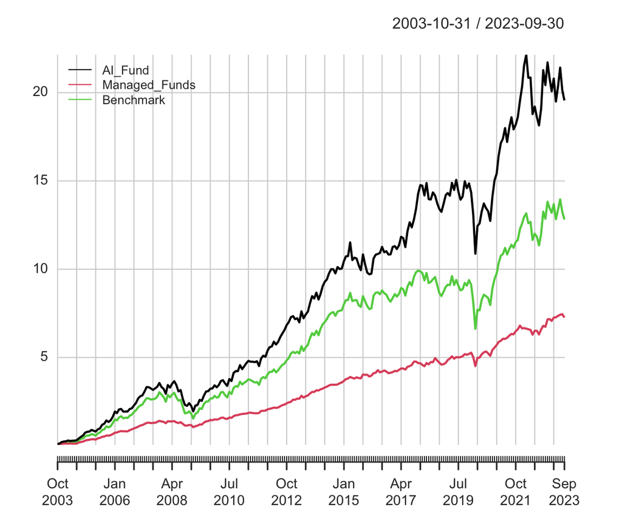

After calculating cumulative returns to assess overall performance, rolling returns are analyzed to evaluate consistency and resilience over different time periods, addressing potential biases from early outcomes or isolated events.

This plot aligns with the general conclusions from the previous plot but provides a more granular view of short-term performance trends over time.